# Disease effect time uncertainty modeling in lgpr

Juho Timonen

2025-10-30

```r
require("lgpr")
# Loading required package: lgpr
# Attached lgpr 1.2.5, using rstan 2.32.7. Type ?lgpr to get started.
require("ggplot2")
# Loading required package: ggplot2
require("rstan")
# Loading required package: rstan
# Loading required package: StanHeaders
#
# rstan version 2.32.7 (Stan version 2.32.2)
# For execution on a local, multicore CPU with excess RAM we recommend calling
# options(mc.cores = parallel::detectCores()).
# To avoid recompilation of unchanged Stan programs, we recommend calling
# rstan_options(auto_write = TRUE)
# For within-chain threading using `reduce_sum()` or `map_rect()` Stan functions,
# change `threads_per_chain` option:
# rstan_options(threads_per_chain = 1)
```

# 1 Introduction

In this tutorial we simulate and analyse a test data set which contains 6 case and 6 control individuals, and the disease effect on case individuals is modeled using the disease-related age (`diseaseAge`) as a covariate. The disease-related age is defined as age relative to the observed disease initiation. The true disease effect times for each case individual $q=1, \ldots,6$ are drawn from $\mathcal{N}(36,4^2)$, but the disease initiation is observable only after time $t_q$ , which is drawn from $t_q∼\text{Exponential}(0.05)$ .

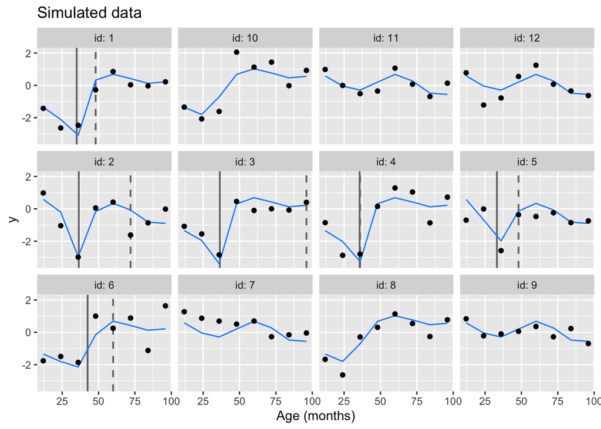

```r
set.seed(121)
relev <- c(0, 1, 1, 1, 0, 0)
effect_time_fun <- function() {
  rnorm(n = 1, mean = 36, sd = 4)
}
obs_fun <- function(t) {
  min(t + stats::rexp(n = 1, rate = 0.05), 96 - 1e-5)
}

simData <- simulate_data(
  N = 12,
  t_data = seq(12, 96, by = 12),
  covariates = c(0, 2, 2, 2),
  relevances = relev,
  lengthscales = c(18, 24, 1.1, 18, 18, 18),
  t_effect_range = effect_time_fun,
  t_observed = obs_fun,
  snr = 3
)

plot_sim(simData) + xlab("Age (months)")
# Warning: `aes_string()` was deprecated in ggplot2 3.0.0.
# ℹ Please use tidy evaluation idioms with `aes()`.
# ℹ See also `vignette("ggplot2-in-packages")` for more information.
# ℹ The deprecated feature was likely used in the lgpr package.
#   Please report the issue at <https://github.com/jtimonen/lgpr/issues>.
# This warning is displayed once every 8 hours.
# Call `lifecycle::last_lifecycle_warnings()` to see where this warning was generated.
# - Dots are noisy observations of the response var.
# - Line is the true signal mapped through inv. link fun.
# - Solid vert. line is the real effect time (used to generate signal)
# - Dashed vert. line is the 'observed' disease initiation time
```

```r
# plot_sim(simData, comp_idx = 3) # to visualize one generated component
```

Above, the blue line represents the data-generating signal and black dots are noisy observations of the response variable.

```r
dat <- simData@data
str(dat)
# 'data.frame': 96 obs. of  7 variables:
#  $ id        : Factor w/ 12 levels "1","2","3","4",..: 1 1 1 1 1 1 1 1 2 2 ...
#  $ age       : num  12 24 36 48 60 72 84 96 12 24 ...
#  $ diseaseAge: num  -36 -24 -12 0 12 24 36 48 -60 -48 ...
#  $ z1        : Factor w/ 2 levels "1","2": 2 2 2 2 2 2 2 2 1 1 ...
#  $ z2        : Factor w/ 2 levels "1","2": 2 2 2 2 2 2 2 2 2 2 ...
#  $ z3        : Factor w/ 2 levels "1","2": 2 2 2 2 2 2 2 2 2 2 ...
#  $ y         : num  -1.42 -2.632 -2.467 -0.275 0.857 ...
simData@effect_times
# $true
#        1        2        3        4        5        6        7        8
# 34.97856 36.43350 36.51112 35.67571 33.14527 42.46133      NaN      NaN
#        9       10       11       12
#      NaN      NaN      NaN      NaN
#
# $observed
#   1   2   3   4   5   6   7   8   9  10  11  12
#  48  72  96  36  48  60 NaN NaN NaN NaN NaN NaN
```

# 2 Declaring effect time uncertainty

We will define a formula where the term `unc(id)*gp_vm(diseaseAge)` declares that the effect time for the nonstationary `gp_vm` term is uncertain and that one uncertainty parameter is needed for each level of `id`.

```r
formula <- y ~ zs(id) * gp(age) + gp(age) + unc(id) * gp_vm(diseaseAge) + zs(z1) * gp(age) + zs(z2) * gp(age) + zs(z3) * gp(age)
```

Because `diseaseAge` is `NaN` for the control individuals, it is automatically taken into account that a separate uncertainty parameter is actually needed just for each case individual.

# 3 Defining the effect time prior

Declaring a temporally uncrertain component will add parameters `teff` to the model. The vector `teff` has length equal to the number of case individuals. We must define a prior for each `teff` parameter. This means that the `prior` argument must be a list containing elements named `effect_time` and `effect_time_info`. The first one is specified using any of the basic prior definition functions, like `uniform()`, `normal()`, etc. The second one, `effect_time_info`, must be a named list containing the fields

- `zero` - this is a vector with same length as `teff`, and can be used to move the center of the prior
- `backwards` - this is a boolean value, and the prior defined in `effect_time` will be for
  - `(teff - zero)` if `backwards = FALSE`
  - `- (teff - zero)` if `backwards = TRUE`
- `lower` - this is a vector with same length as `teff`, and defines the lower bound for each `teff` parameter
- `upper` - this is a vector with same length as `teff`, and defines the upper bound for each `teff` parameter

You can give `zero`, `lower`, and `upper` also as just one number, in which case they are turned into vectors that repeat the save value. The prior defined in `effect_time` will be truncated at lower and upper bounds.

## 3.1 Prior for the effect time directly

We had observed the disease onset at times $48,72,96,36,48,60$ months for each case individual, respectively. Now if think that the true effect of the disease has occurred for each indiviaul at some time point before the detection of the disease, but not before age $18$ months, we could set the prior like here.

```r
obs_onset <- c(48, 72, 96, 36, 48, 60)
lb <- 18
ub <- obs_onset
effect_time_info <- list(zero = 0, backwards = FALSE, lower = lb, upper = ub)
my_prior <- list(
  effect_time = uniform(), # between lb and ub
  effect_time_info = effect_time_info,
  wrp = igam(14, 5) # see how to set this in the 'Basic usage' tutorial
)
```

## 3.2 Prior relative to a known time point

It is possible that we want a prior where values closer to the observed onset are more likely than those closer to birth. This can be done by defining for example an exponentially decaying prior for `- (teff - obs_onset)`, as is done here.

```r
lb <- 18
ub <- obs_onset
effect_time_info <- list(zero = ub, backwards = TRUE, lower = lb, upper = ub)
my_prior <- list(
  wrp = igam(14, 5),
  effect_time_info = effect_time_info,
  effect_time = gam(shape = 1, inv_scale = 0.05) # = Exponential(rate=0.05)
)
```

Now our uncertainty priors are actually for time differences relative to the observed disease initiation time, and `backwards = TRUE` argument is used to define the direction so that the prior is “backwards” in time. We used `gam()` because the Gamma distribution with `shape=1` and `inv_scale=lambda` is equal to the Exponential distribution with `rate= lambda`.